# Tugas 5 MPDW

Azzahra Adelia Putri

2023-10-02

## Pemanggilan Packages

```r
library(ggplot2)
library(tsibble)
library(tseries)
library(MASS)
library(readxl)
```

## Impor Data

```r
data <- read_excel("C:/Users/Asus/Downloads/data suhu palembang.xlsx", sheet=2)
head(data)
```

```
## # A tibble: 6 × 2
##   date                 temp
##   <dttm>              <dbl>
## 1 2021-04-11 00:00:00  28.2
## 2 2021-04-12 00:00:00  28.2
## 3 2021-04-13 00:00:00  28.4
## 4 2021-04-14 00:00:00  28.3
## 5 2021-04-15 00:00:00  28.1
## 6 2021-04-16 00:00:00  28.1
```

## Semua Data

### Ubah ke data Time Series

```r
data.ts <- ts(data$temp)
```

### Plot Time Series

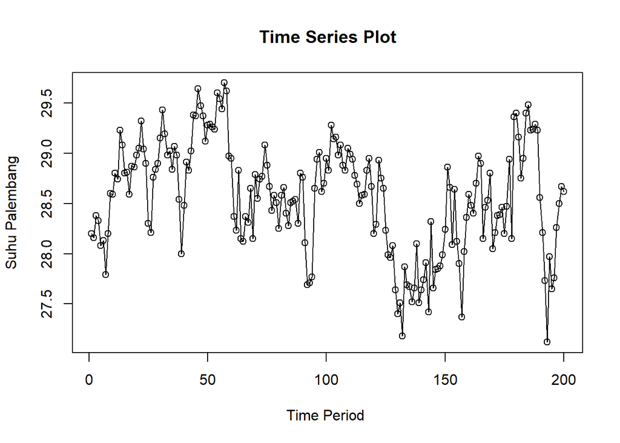

```r
ts.plot(data.ts, xlab="Time Period ", ylab="Suhu Palembang",
        main = "Time Series Plot")
points(data.ts)
```

```r
mean(data.ts)
```

```
## [1] 28.57005
```

Plot deret waktu di atas menunjukkan bahwa data tidak stasioner dalam rataan, ditandai dengan data yang tidak menyebar di sekitar nilai tengahnya dan stasioner dalam ragam, ditandai dengan lebar pita yang cenderung sama.

### Plot ACF

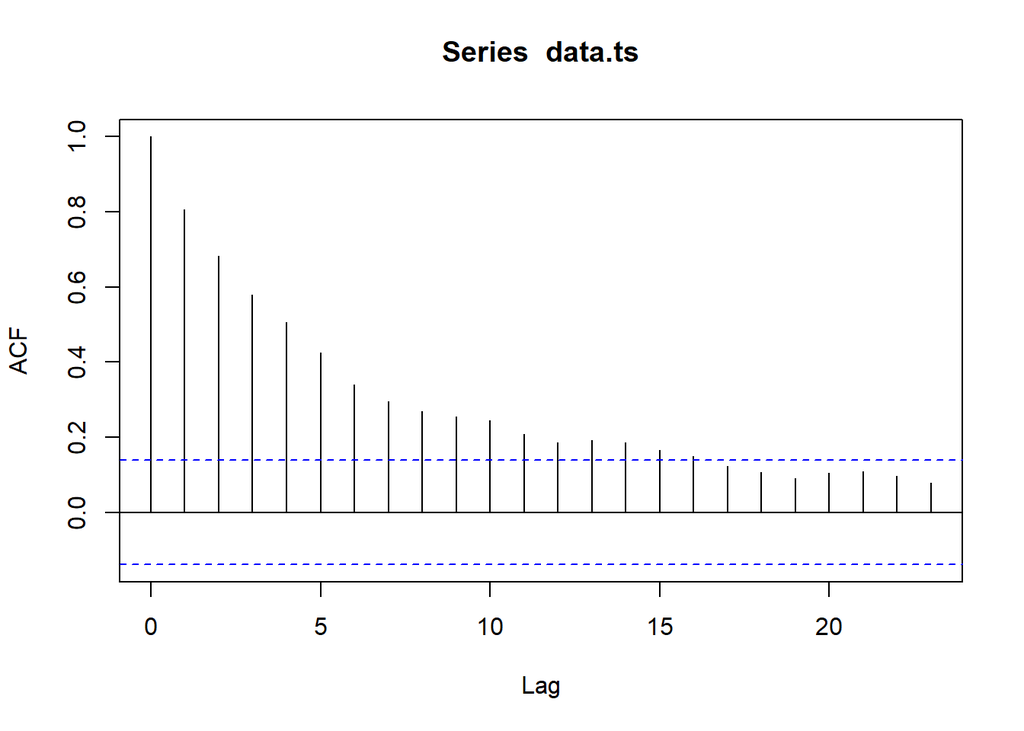

```r
acf(data.ts)
```

Berdasarkan plot ACF, terlihat bahwa plot ACF pada data tersebut cenderung *tails off slowly*, maka data tidak stasioner dalam rataan

### Plot ADF

```r
tseries::adf.test(data.ts, k=8)
```

```
##
##  Augmented Dickey-Fuller Test
##
## data:  data.ts
## Dickey-Fuller = -3.1515, Lag order = 8, p-value = 0.09755
## alternative hypothesis: stationary
```

$H_0$ : Data tidak stasioner dalam rataan

$H_1$ : Data stasioner dalam rataan

Berdasarkan uji ADF tersebut, didapat *p-value* sebesar 0.09755 yang lebih besar dari taraf nyata 5% sehingga tak tolak $H_0$ dan menandakan bahwa data tidak stasioner dalam rataan. Hal ini sesuai dengan hasil eksplorasi menggunakan plot time series dan plot ACF.

### Plot Box Cox

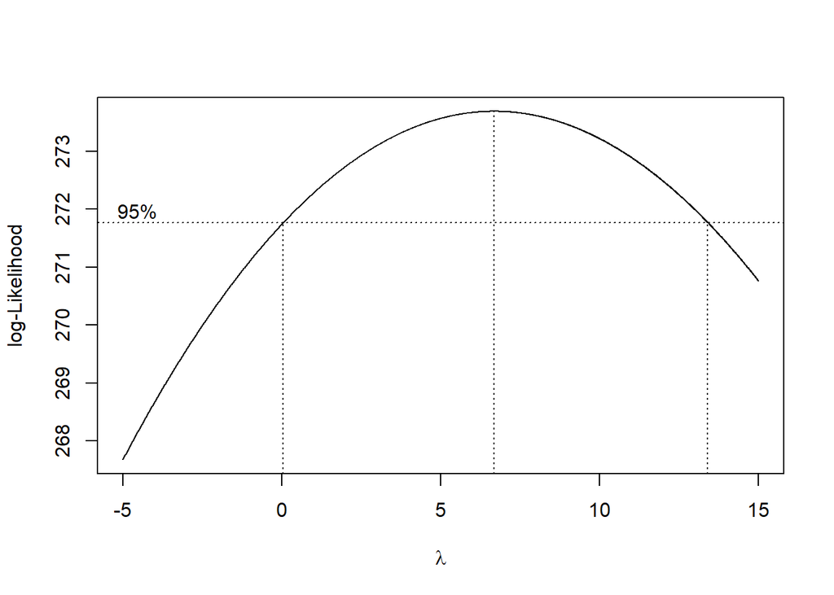

```r
index <- seq(1:200)
bc = boxcox(data.ts~index, lambda = seq(-5,15,by=0.01))
```

```r
#Nilai Rounded Lambda
lambda <- bc$x[which.max(bc$y)]
lambda
```

```
## [1] 6.68
```

```r
#SK
bc$x[bc$y > max(bc$y) - 1/2 * qchisq(.95,1)]
```

```
##    [1]  0.05  0.06  0.07  0.08  0.09  0.10  0.11  0.12  0.13  0.14  0.15  0.16
##   [13]  0.17  0.18  0.19  0.20  0.21  0.22  0.23  0.24  0.25  0.26  0.27  0.28
##   [25]  0.29  0.30  0.31  0.32  0.33  0.34  0.35  0.36  0.37  0.38  0.39  0.40
##   [37]  0.41  0.42  0.43  0.44  0.45  0.46  0.47  0.48  0.49  0.50  0.51  0.52
##   [49]  0.53  0.54  0.55  0.56  0.57  0.58  0.59  0.60  0.61  0.62  0.63  0.64
##   [61]  0.65  0.66  0.67  0.68  0.69  0.70  0.71  0.72  0.73  0.74  0.75  0.76
##   [73]  0.77  0.78  0.79  0.80  0.81  0.82  0.83  0.84  0.85  0.86  0.87  0.88
##   [85]  0.89  0.90  0.91  0.92  0.93  0.94  0.95  0.96  0.97  0.98  0.99  1.00
##   [97]  1.01  1.02  1.03  1.04  1.05  1.06  1.07  1.08  1.09  1.10  1.11  1.12
##  [109]  1.13  1.14  1.15  1.16  1.17  1.18  1.19  1.20  1.21  1.22  1.23  1.24
##  [121]  1.25  1.26  1.27  1.28  1.29  1.30  1.31  1.32  1.33  1.34  1.35  1.36
##  [133]  1.37  1.38  1.39  1.40  1.41  1.42  1.43  1.44  1.45  1.46  1.47  1.48
##  [145]  1.49  1.50  1.51  1.52  1.53  1.54  1.55  1.56  1.57  1.58  1.59  1.60
##  [157]  1.61  1.62  1.63  1.64  1.65  1.66  1.67  1.68  1.69  1.70  1.71  1.72
##  [169]  1.73  1.74  1.75  1.76  1.77  1.78  1.79  1.80  1.81  1.82  1.83  1.84
```

[output cut: 97 more lines]

Gambar di atas menunjukkan nilai *rounded value* ($\lambda$) optimum sebesar **6.68** dan pada selang kepercayaan 95% nilai memiliki batas bawah **0,05** dan batas atas **13.41**. Selang tersebut memuat nilai satu sehingga dapat dikatakan bahwa data bangkitan stasioner dalam ragam.

Kesimpulan : Stasioner dalam Ragam, Tidak stasioner dalam Rataan

## Partisi Data

### Bagian 1

```r
data.ts1 <- data.ts[1:126] |> ts()
mean(data.ts1)
```

```
## [1] 28.74556
```

```r
var(data.ts1)
```

```
## [1] 0.1860393
```

#### Plot Time Series

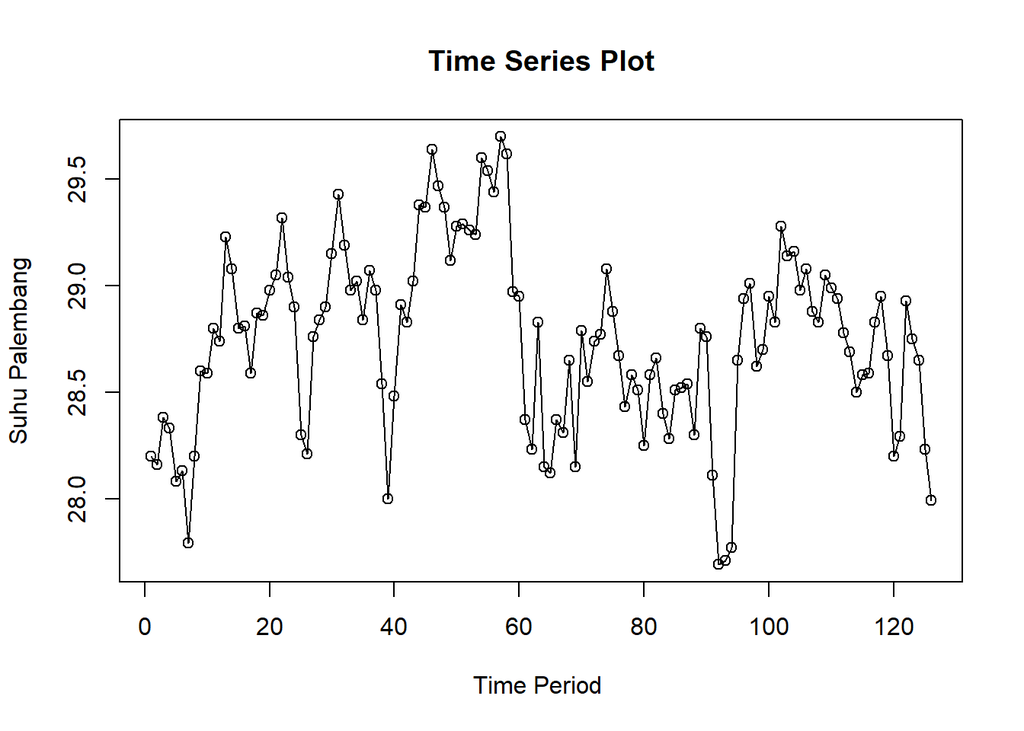

```r
ts.plot(data.ts1, xlab="Time Period ", ylab="Suhu Palembang",
        main = "Time Series Plot")
points(data.ts1)
```

```r
mean(data.ts1)
```

```
## [1] 28.74556
```

Berdasarkan plot time series tersebut, terlihat bahwa data tidak stasioner dalam rataan, ditandai dengan adanya trend pada data dan stasioner dalam ragam, ditandai dengan lebar pita pada plot cenderung sama.

#### Plot ACF

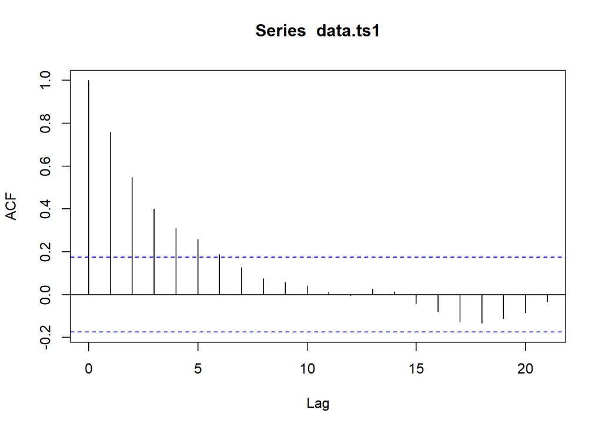

```r
acf(data.ts1)
```

Berdasarkan plot ACF, terlihat bahwa plot ACF pada data tersebut menurun secara perlahan (*tails off slowly*) yang menandakan data tidak stasioner dalam rataan

#### Plot ADF

```r
tseries::adf.test(data.ts1)
```

```
##
##  Augmented Dickey-Fuller Test
##
## data:  data.ts1
## Dickey-Fuller = -3.2994, Lag order = 4, p-value = 0.07454
## alternative hypothesis: stationary
```

$H_0$ : Data tidak stasioner dalam rataan

$H_1$ : Data stasioner dalam rataan

### Plot Box Cox

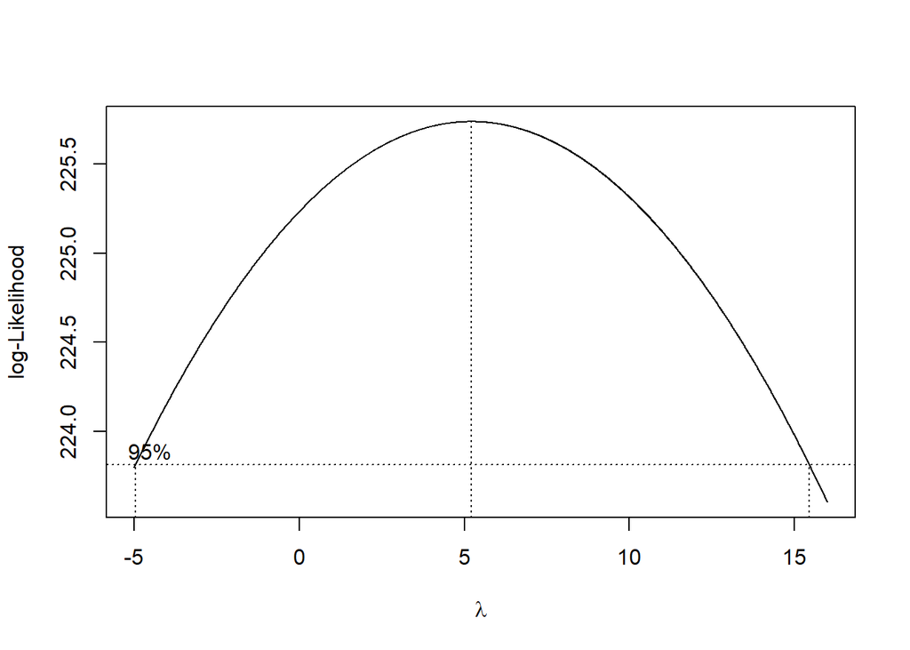

```r
index <- seq(1:126)
bc = boxcox(data.ts1~index, lambda = seq(-5,16,by=0.01))
```

```r
#Nilai Rounded Lambda
lambda <- bc$x[which.max(bc$y)]
lambda
```

```
## [1] 5.21
```

```r
#SK
bc$x[bc$y > max(bc$y) - 1/2 * qchisq(.95,1)]
```

```
##    [1] -4.95 -4.94 -4.93 -4.92 -4.91 -4.90 -4.89 -4.88 -4.87 -4.86 -4.85 -4.84
##   [13] -4.83 -4.82 -4.81 -4.80 -4.79 -4.78 -4.77 -4.76 -4.75 -4.74 -4.73 -4.72
##   [25] -4.71 -4.70 -4.69 -4.68 -4.67 -4.66 -4.65 -4.64 -4.63 -4.62 -4.61 -4.60
##   [37] -4.59 -4.58 -4.57 -4.56 -4.55 -4.54 -4.53 -4.52 -4.51 -4.50 -4.49 -4.48
##   [49] -4.47 -4.46 -4.45 -4.44 -4.43 -4.42 -4.41 -4.40 -4.39 -4.38 -4.37 -4.36
##   [61] -4.35 -4.34 -4.33 -4.32 -4.31 -4.30 -4.29 -4.28 -4.27 -4.26 -4.25 -4.24
##   [73] -4.23 -4.22 -4.21 -4.20 -4.19 -4.18 -4.17 -4.16 -4.15 -4.14 -4.13 -4.12
##   [85] -4.11 -4.10 -4.09 -4.08 -4.07 -4.06 -4.05 -4.04 -4.03 -4.02 -4.01 -4.00
##   [97] -3.99 -3.98 -3.97 -3.96 -3.95 -3.94 -3.93 -3.92 -3.91 -3.90 -3.89 -3.88
##  [109] -3.87 -3.86 -3.85 -3.84 -3.83 -3.82 -3.81 -3.80 -3.79 -3.78 -3.77 -3.76
##  [121] -3.75 -3.74 -3.73 -3.72 -3.71 -3.70 -3.69 -3.68 -3.67 -3.66 -3.65 -3.64
##  [133] -3.63 -3.62 -3.61 -3.60 -3.59 -3.58 -3.57 -3.56 -3.55 -3.54 -3.53 -3.52
##  [145] -3.51 -3.50 -3.49 -3.48 -3.47 -3.46 -3.45 -3.44 -3.43 -3.42 -3.41 -3.40
##  [157] -3.39 -3.38 -3.37 -3.36 -3.35 -3.34 -3.33 -3.32 -3.31 -3.30 -3.29 -3.28
##  [169] -3.27 -3.26 -3.25 -3.24 -3.23 -3.22 -3.21 -3.20 -3.19 -3.18 -3.17 -3.16
```

[output cut: 155 more lines]

Kesimpulan : Stasioner dalam Ragam, Tidak Stasioner dalam Rataan

### Bagian 2

```r
data.ts2 <- data.ts[1:160] |> ts()
mean(data.ts2)
```

```
## [1] 28.56769
```

```r
var(data.ts2)
```

```
## [1] 0.2976707
```

#### Plot Time Series

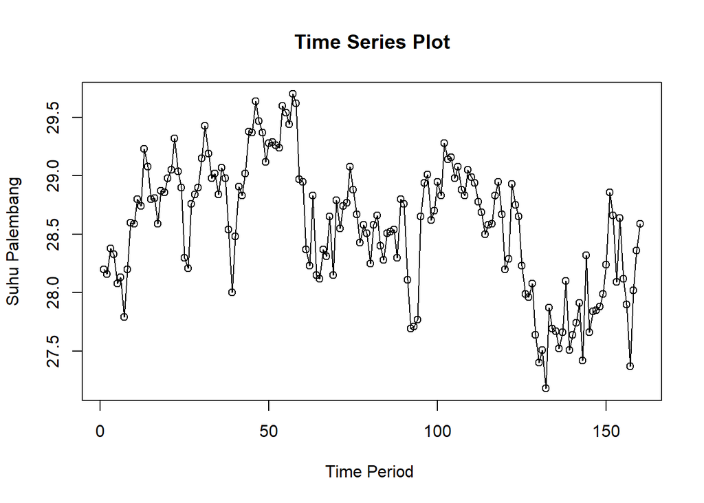

```r
ts.plot(data.ts2, xlab="Time Period ", ylab="Suhu Palembang",
        main = "Time Series Plot")
points(data.ts2)
```

```r
mean(data.ts2)
```

```
## [1] 28.56769
```

#### Plot ACF

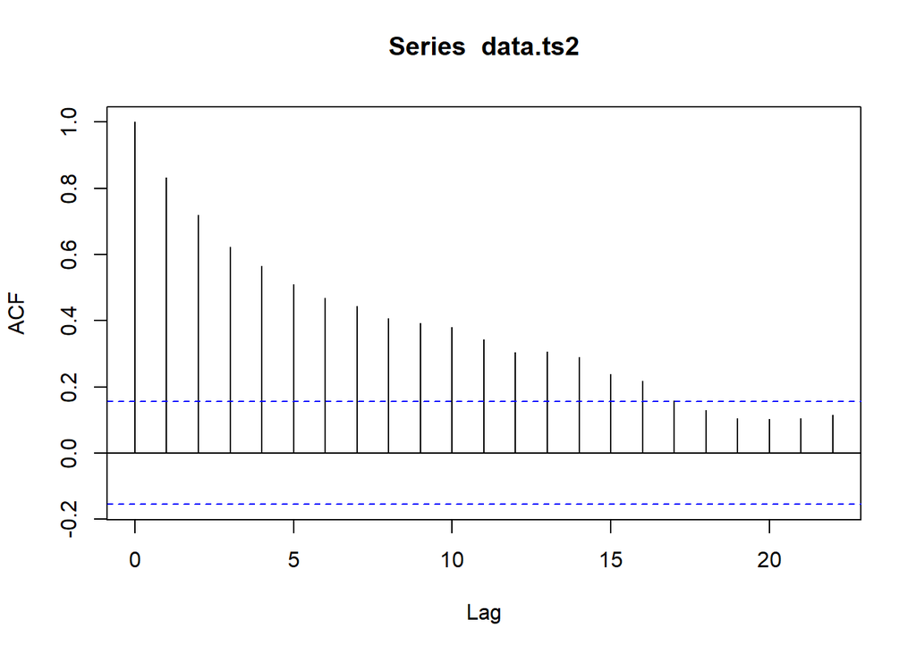

```r
acf(data.ts2)
```

Berdasarkan plot ACF, terlihat bahwa plot ACF pada data tersebut menurun secara perlahan (*tails off slowly*) yang menandakan data tidak stasioner dalam rataan

#### Plot ADF

```r
tseries::adf.test(data.ts1)
```

[output not shown]

$H_0$ : Data tidak stasioner dalam rataan

$H_1$ : Data stasioner dalam rataan

### Plot Box Cox

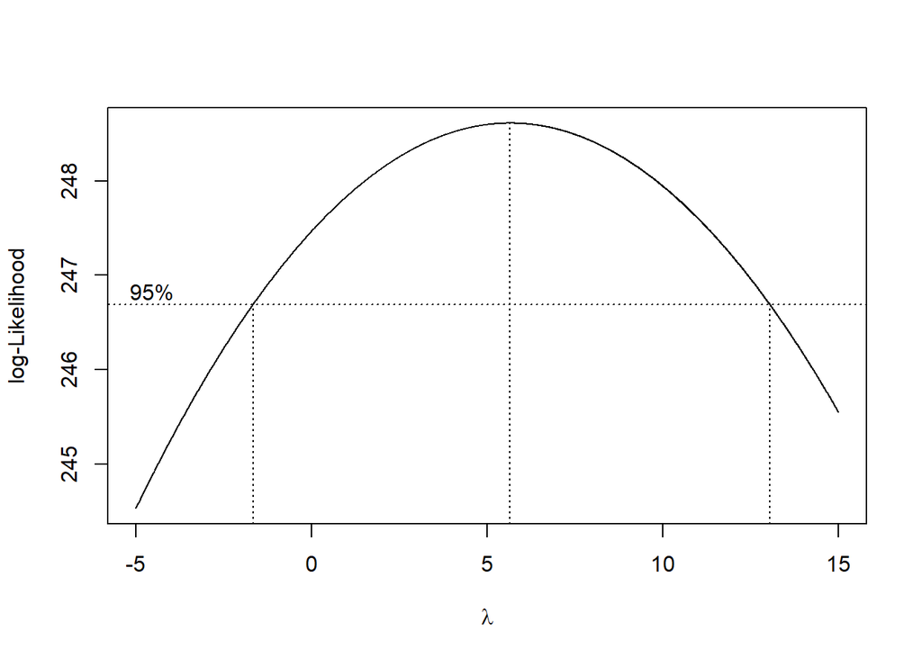

```r
index <- seq(1:160)
bc = boxcox(data.ts2~index, lambda = seq(-5,15,by=0.01))
```

```r
#Nilai Rounded Lambda
lambda <- bc$x[which.max(bc$y)]
lambda
```

```
## [1] 5.65
```

```r
#SK
bc$x[bc$y > max(bc$y) - 1/2 * qchisq(.95,1)]
```

```
##    [1] -1.66 -1.65 -1.64 -1.63 -1.62 -1.61 -1.60 -1.59 -1.58 -1.57 -1.56 -1.55
##   [13] -1.54 -1.53 -1.52 -1.51 -1.50 -1.49 -1.48 -1.47 -1.46 -1.45 -1.44 -1.43
##   [25] -1.42 -1.41 -1.40 -1.39 -1.38 -1.37 -1.36 -1.35 -1.34 -1.33 -1.32 -1.31
##   [37] -1.30 -1.29 -1.28 -1.27 -1.26 -1.25 -1.24 -1.23 -1.22 -1.21 -1.20 -1.19
##   [49] -1.18 -1.17 -1.16 -1.15 -1.14 -1.13 -1.12 -1.11 -1.10 -1.09 -1.08 -1.07
##   [61] -1.06 -1.05 -1.04 -1.03 -1.02 -1.01 -1.00 -0.99 -0.98 -0.97 -0.96 -0.95
##   [73] -0.94 -0.93 -0.92 -0.91 -0.90 -0.89 -0.88 -0.87 -0.86 -0.85 -0.84 -0.83
##   [85] -0.82 -0.81 -0.80 -0.79 -0.78 -0.77 -0.76 -0.75 -0.74 -0.73 -0.72 -0.71
##   [97] -0.70 -0.69 -0.68 -0.67 -0.66 -0.65 -0.64 -0.63 -0.62 -0.61 -0.60 -0.59
##  [109] -0.58 -0.57 -0.56 -0.55 -0.54 -0.53 -0.52 -0.51 -0.50 -0.49 -0.48 -0.47
##  [121] -0.46 -0.45 -0.44 -0.43 -0.42 -0.41 -0.40 -0.39 -0.38 -0.37 -0.36 -0.35
##  [133] -0.34 -0.33 -0.32 -0.31 -0.30 -0.29 -0.28 -0.27 -0.26 -0.25 -0.24 -0.23
##  [145] -0.22 -0.21 -0.20 -0.19 -0.18 -0.17 -0.16 -0.15 -0.14 -0.13 -0.12 -0.11
##  [157] -0.10 -0.09 -0.08 -0.07 -0.06 -0.05 -0.04 -0.03 -0.02 -0.01  0.00  0.01
##  [169]  0.02  0.03  0.04  0.05  0.06  0.07  0.08  0.09  0.10  0.11  0.12  0.13
```

[output cut: 108 more lines]

Gambar di atas menunjukkan nilai *rounded value* ($\lambda$) optimum sebesar **5.65** dan pada selang kepercayaan 95% nilai memiliki batas bawah **-1.66** dan batas atas **13.04**. Selang tersebut memuat nilai satu sehingga dapat dikatakan bahwa data bangkitan stasioner dalam ragam.

Kesimpulan : Stasioner dalam Ragam, Tidak Stasioner dalam Rataan